# Annotation of a soil fungus

Redmine issue: 5123

NBIS staff: Nima Rafati

22 Februari, 2021

# Project information

- Redmine issue: **5123**
- NBIS staff: **Nima Rafati**
- Request by: **David Manyara**
- Principal investigator: **Anna Rosling**
- Organisation: **UU**

# Work log

*A brief summary if the project’s key points.*

- **2018-12-19:** Meeting with the group to plan data analyses

# Practical information

## Data responsibilities

Unfortunately, NBIS does not have resources to keep any files associated with the support request; we kindly suggest that you safely store the results delivered by us. In addition, we kindly ask that you remove the files from UPPMAX/UPPNEX. The main storage at UPPNEX is optimized for high-speed and parallel access, which makes it expensive and not the right place for long-term archiving. Please be considerate of your fellow researchers by not taking up this expensive space.

The responsibility for data archiving lies with universities and we recommend asking your local IT for support with long-term data storage. The [Data Center](https://www.scilifelab.se/data/) at SciLifeLab may also be of help with discussing other options.

Please note that special considerations may apply to human-derived, sensitive personal data. This should be handled according to specific laws and regulations as outlined at the [NBIS website](https://nbis.se/support/human-data.html).

## Acknowledgements

If you are presenting the results in a paper, at a workshop or at a conference, we kindly remind you to acknowledge us according to the signed [NBIS User Agreement](http://nbis.se/assets/doc/nbis-support-useragreement.pdf):

[NBIS staff should be included as co-authors](https://nbis.se/about/staff/nima-rafati/) if the support work leads to a publication and when this is merited in accordance to the ethical recommendations for authorship, *i.e.* the [ICMJE recommendations](http://www.icmje.org/recommendations/). If applicable, please include *Nima Rafati, National Bioinformatics Infrastructure Sweden, Science for Life Laboratory, Stockholm University* as co-author. If the above is not applicable, please acknowledge NBIS like so: *Support by NBIS (National Bioinformatics Infrastructure Sweden) is gratefully acknowledged.*

In addition, Uppmax kindly asks you to [acknowledge UPPMAX and SNIC](http://uppmax.uu.se/support-sv/faq/general-%20miscellaneous-faq/acknowledging-uppmax--snic--and-uppnex). If applicable, please add: *The computations were performed on resources provided by SNIC through Uppsala Multidisciplinary Center for Advanced Computational Science (UPPMAX) under Project snic2020-16-21 (Storage) snic2020-5-245 (Computation).*

In any and all publications based on data from NGI Sweden, the authors must [acknowledge SciLifeLab, NGI and Uppmax](https://ngisweden.scilifelab.se/info/faq#how-do%20-i-acknowledge-ngi-in-my-publication), like so: *The authors would like to acknowledge support from Science for Life Laboratory, the National Genomics Infrastructure, NGI, and Uppmax for providing assistance in massive parallel sequencing and computational infrastructure.*

## Closing procedures

You should soon be contacted by one of our managers, Jessica Lindvall *(jessica.lindvall@nbis.se)* or Henrik Lantz *(henrik.lantz@nbis.se)*, with a request to close down the project in our internal system and for invoicing matters. If we do not hear from you within **30 days** the project will be automatically closed and invoice sent. Again, we would like to remind you about data responsibility and acknowledgements, see the sections on data responsibilities and acknowledgments.

You are naturally more than welcome to come back to us with further data analysis request at any time via [the support form](http://nbis.se/support/support.html). Thank you for using NBIS, we wish you the best of luck with your future research!

# Methods

## Genome preparation

### Alignment

We aligned trimmed reads on Sorghum and AM_fungi genome by STAR(Dobin et al. 2012) and GSNAP(Wu and Watanabe 2005). These two genomes were provided by David Manyara. We first evaluated the aligners and the results showed that GSNAP had a better statistics. Thus, all the results provided here is based on GSNAp alignment. To select species specific reads, we used Disambiguate tool (Ahdesmäki et al. 2017) and XenofilteR(Kluin et al. 2018). These tools assign reads to corresponding species based on edit distance. We evaluated performance of these tools and XenofilteR could rescue more accurate alignments. We tested different edit distances to assign the reads. After mapping we used QoRTs (Hartley and Mullikin 2015) to check the quality of the alignments.

## Expression analysis

We extracted fragment counts of all genes by using featurecounts(Liao, Smyth, and Shi 2014). We used reads with mapping quality +20 and paris that are properly mapped on the same contig.

# Results

Summary of sequencing data; Number of trimmed reads.

| Sample | Trimmed_paired_reads |
| --- | --- |
| 31B | 30405701 |
| 32A | 21132972 |
| 32B | 36903891 |
| 33A | 28592911 |
| 33B | 27192272 |
| 34A | 33302494 |
| 34B | 27758826 |
| 35A | 29492958 |
| 35B | 28209350 |
| 36A | 31472821 |
| 37B | 35355301 |
| 38B | 27676494 |
| 39B | 27188497 |
| 40B | 34563906 |
| 41B | 33230341 |
| 42B | 36158716 |
| 43B | 36548792 |
| 44B | 36143450 |
| 45B | 31164207 |
| 46B | 38477147 |
| 48B | 42409786 |

## QC

The QC results is available in */crex/proj/uppstore2017083/private/SMS_5123_20_AM_fungi_annotation/results/00-QC/* The duplication rate is a bit high in the raw reads (Please check the multiQC report).

## Trimming

By using Trimmomatic, we kept reads that both pairs survived the trimming and reads with +36 bases length. Trimmed reads are located in */crex/proj/uppstore2017083/private/SMS_5123_20_AM_fungi_annotation/data/Trimmed_reads/*

## Alignment

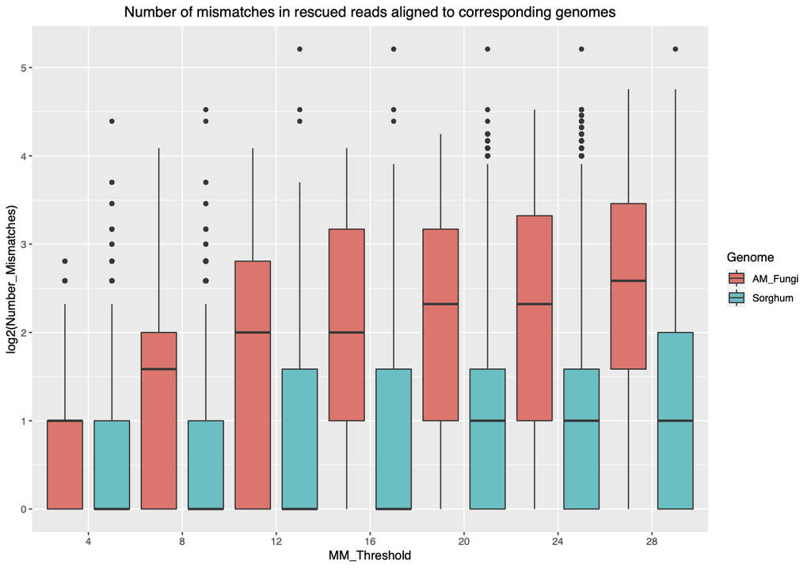

Distribution of nM (number of mismatches) in aligned reads after assigning to corresponding genome.

Ahdesmäki, Miika J., Simon R. Gray, Justin H. Johnson, and Zhongwu Lai. 2017. “Disambiguate: An open-source application for disambiguating two species in next generation sequencing data from grafted samples.” *F1000Research* 5 (January): 2741. https://doi.org/10.12688/f1000research.10082.2.

Andrews, S. n.d. “FastQC A Quality Control tool for High Throughput Sequence Data.” citeulike-article-id:11583827 http://www.bioinformatics.babraham.ac.uk/projects/fastqc/.

Bolger, Anthony M, Marc Lohse, and Bjoern Usadel. 2014. “Trimmomatic: a flexible trimmer for Illumina sequence data.” *Bioinformatics* 30 (15): 2114–20. https://doi.org/10.1093/bioinformatics/btu170.

Dobin, Alexander, Carrie A. Davis, Felix Schlesinger, Jorg Drenkow, Chris Zaleski, Sonali Jha, Philippe Batut, Mark Chaisson, and Thomas R. Gingeras. 2012. “STAR: ultrafast universal RNA-seq aligner.” *Bioinformatics* 29 (1): 15–21. https://doi.org/10.1093/bioinformatics/bts635.

Ewels, Philip, Måns Magnusson, Sverker Lundin, and Max Käller. 2016. “MultiQC: summarize analysis results for multiple tools and samples in a single report.” *Bioinformatics* 32 (19): 3047–48. https://doi.org/10.1093/bioinformatics/btw354.

———. 2016. “MultiQC: summarize analysis results for multiple tools and samples in a single report.” *Bioinformatics* 32 (19): 3047–48. https://doi.org/10.1093/bioinformatics/btw354.

Hartley, Stephen W, and James C Mullikin. 2015. “QoRTs: a comprehensive toolset for quality control and data processing of RNA-Seq experiments.” *BMC Bioinformatics* 16 (1): 224. https://doi.org/10.1186/s12859-015-0670-5.

Kluin, Roelof J C, Kristel Kemper, Thomas Kuilman, Julian R de Ruiter, Vivek Iyer, Josep V Forment, Paulien Cornelissen-Steijger, et al. 2018. “XenofilteR: computational deconvolution of mouse and human reads in tumor xenograft sequence data.” *BMC Bioinformatics* 19 (1): 366. https://doi.org/10.1186/s12859-018-2353-5.

Liao, Yang, Gordon K Smyth, and Wei Shi. 2014. “featureCounts: an efficient general purpose program for assigning sequence reads to genomic features.” *Bioinformatics* 30 (7): 923–30. https://doi.org/10.1093/bioinformatics/btt656.

Palmer, J. 2017. “Funannotate: Fungal genome annotation scripts.” https://doi.org/10.5281/zenodo.2604804.

Pertea, Mihaela, Geo M. Pertea, Corina M. Antonescu, Tsung Cheng Chang, Joshua T. Mendell, and Steven L. Salzberg. 2015. “StringTie enables improved reconstruction of a transcriptome from RNA-seq reads.” *Nature Biotechnology* 33 (3): 290–95. https://doi.org/10.1038/nbt.3122.

Quinlan, Aaron R., and Ira M. Hall. 2010. “BEDTools: a flexible suite of utilities for comparing genomic features.” *Bioinformatics* 26 (6): 841–42. https://doi.org/10.1093/bioinformatics/btq033.

Wu, Thomas D., and Colin K. Watanabe. 2005. “GMAP: a genomic mapping and alignment program for mRNA and EST sequences.” *Bioinformatics* 21 (9): 1859–75. https://doi.org/10.1093/bioinformatics/bti310.